# Data_Preprocessing & Analysis

Akanksha Jondhale

2025-06-10

# Data Cleaning

This report outlines the data cleaning and preprocessing steps applied to the Bellafit datasets. Below is a high-level summary of the actions taken and data readiness status.

18 datasets were imported and processed:

Daily: daily_activity,daily_calories daily_intensities, daily_steps

Hourly: hourly_steps, hourly_intensities, hourly_calories

Minute: minute_mets_narrow,minute_calories_narrow,minute_calories_wide,minute_intensities_narrow,minute_intensities_wide,minute_steps_narrow,minute_steps_wide,minute_sleep_narrow

Heartrate_Seconds and WeightLogInfo

Following datasets we will be using for further analysis:

- daily_activity
- daily_calories
- daily_intensities
- daily_steps
- hourly_calories
- hourly_intensities
- hourly_steps
- minute_mets_narrow

Missing Values: No missing or null values detected in any dataset.

Data Types: All date/time columns were successfully converted to appropriate formats (Date / POSIXct).

Text Cleanup: All character columns were trimmed to remove leading/trailing whitespace.

Column Consistency: Data types were reviewed and validated for each dataset.

## Importing Libraries

```r
library(tidyverse)
```

```r
library(dplyr)
library(ggplot2)
library(purrr)
```

## Importing Data

```r
data_path <- "C:/Users/akank/Downloads/archive (7)/mturkfitbit_export_4.12.16-5.12.16/Fitabase Data 4.12.16-5.12.16/"
daily_activity <- read_csv(paste0(data_path, "dailyActivity_merged.csv"))
daily_calories <- read_csv(paste0(data_path, "dailyCalories_merged.csv"))
daily_intensities <- read_csv(paste0(data_path, "dailyIntensities_merged.csv"))
daily_steps <- read_csv(paste0(data_path, "dailySteps_merged.csv"))
heartrate_seconds <- read_csv(paste0(data_path, "heartrate_seconds_merged.csv"))
hourly_calories <- read_csv(paste0(data_path, "hourlyCalories_merged.csv"))
hourly_intensities <- read_csv(paste0(data_path, "hourlyIntensities_merged.csv"))
hourly_steps <- read_csv(paste0(data_path, "hourlySteps_merged.csv"))
minute_calories_narrow <- read_csv(paste0(data_path, "minuteCaloriesNarrow_merged.csv"))
minute_calories_wide <- read_csv(paste0(data_path, "minuteCaloriesWide_merged.csv"))
minute_intensities_narrow <- read_csv(paste0(data_path, "minuteIntensitiesNarrow_merged.csv"))
minute_intensities_wide <- read_csv(paste0(data_path, "minuteIntensitiesWide_merged.csv"))
minute_mets_narrow <- read_csv(paste0(data_path, "minuteMETsNarrow_merged.csv"))
minute_sleep <- read_csv(paste0(data_path, "minuteSleep_merged.csv"))
minute_steps_narrow <- read_csv(paste0(data_path, "minuteStepsNarrow_merged.csv"))
minute_steps_wide <- read_csv(paste0(data_path, "minuteStepsWide_merged.csv"))
sleep_day <- read_csv(paste0(data_path, "sleepDay_merged.csv"))
weight <- read_csv(paste0(data_path, "weightLogInfo_merged.csv"))
## Create a named list of your datasets
datasets <- list(
  daily_activity = daily_activity,
  daily_calories = daily_calories,
  daily_intensities = daily_intensities,
  daily_steps = daily_steps,
  heartrate_seconds = heartrate_seconds,
  hourly_calories = hourly_calories,
  hourly_intensities = hourly_intensities,
  hourly_steps = hourly_steps,
  minute_calories_narrow = minute_calories_narrow,
  minute_calories_wide = minute_calories_wide,
  minute_intensities_narrow = minute_intensities_narrow,
  minute_intensities_wide = minute_intensities_wide,
  minute_mets_narrow = minute_mets_narrow,
  minute_sleep = minute_sleep,
  minute_steps_narrow = minute_steps_narrow,
  minute_steps_wide = minute_steps_wide,
  sleep_day = sleep_day,
  weight = weight
)

## Now generate a tibble with counts of unique Ids
unique_ids <- tibble(
  Dataset = names(datasets),
  Unique_IDs = sapply(datasets, function(df) n_distinct(df$Id))

)
## View the result
print(unique_ids)
```

```
## # A tibble: 18 × 2
##    Dataset                   Unique_IDs
##    <chr>                          <int>
##  1 daily_activity                    33
##  2 daily_calories                    33
##  3 daily_intensities                 33
##  4 daily_steps                       33
##  5 heartrate_seconds                 14
##  6 hourly_calories                   33
##  7 hourly_intensities                33
##  8 hourly_steps                      33
##  9 minute_calories_narrow            33
## 10 minute_calories_wide              33
## 11 minute_intensities_narrow         33
## 12 minute_intensities_wide           33
## 13 minute_mets_narrow                33
## 14 minute_sleep                      24
## 15 minute_steps_narrow               33
## 16 minute_steps_wide                 33
## 17 sleep_day                         24
## 18 weight                             8
```

Since heartrate_seconds has only 14 unique users,weightlogInfo has 8,minuteSleep and sleep day have 24 unique users.We can drop those tables. We can also drop tables having user info at minute level about their calories,step,intensities since it contains same aggregated data at hour level.

```r
## Remove unwanted tibbles from Global Environment
rm(heartrate_seconds, minute_calories_narrow, minute_calories_wide, minute_intensities_wide, minute_intensities_narrow,
   minute_steps_narrow, minute_steps_wide, minute_sleep, sleep_day, weight)
```

```r
gc()
```

```
##            used  (Mb) gc trigger  (Mb) max used  (Mb)
## Ncells  2014180 107.6    3833900 204.8  2972622 158.8
## Vcells 35078548 267.7   60834814 464.2 49302243 376.2
```

## Give record counts for datasets

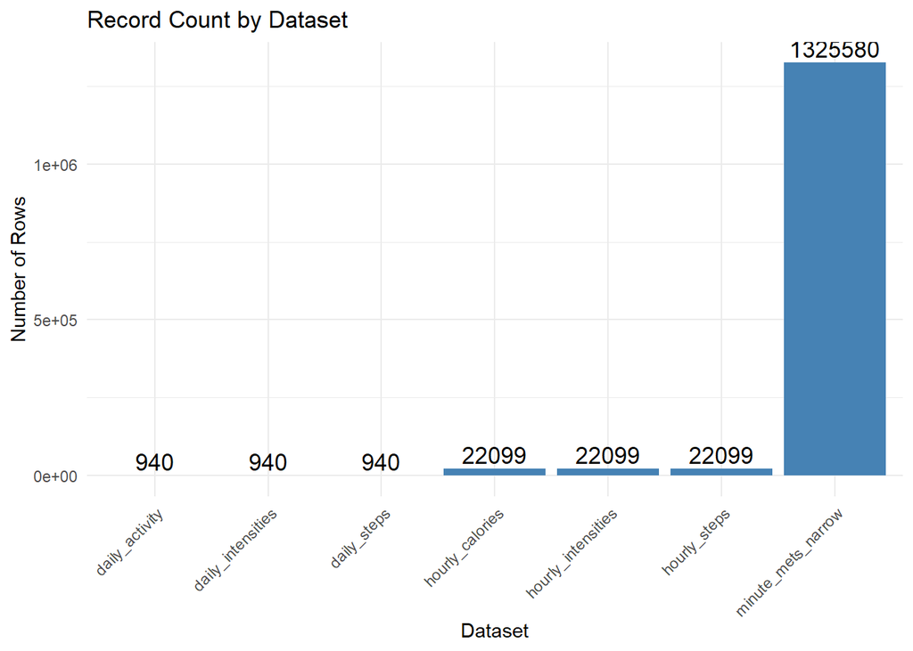

```r
## List of datasets
datasets <- list(
  daily_activity = daily_activity,
  daily_intensities = daily_intensities,
  daily_steps = daily_steps,
  hourly_steps = hourly_steps,
  hourly_intensities = hourly_intensities,
  hourly_calories = hourly_calories,
  minute_mets_narrow = minute_mets_narrow
)

record_counts <- tibble(
  Dataset = names(datasets),
  Rows = map_int(datasets, nrow)
)

ggplot(record_counts, aes(x = Dataset, y = Rows)) +
  geom_bar(stat = "identity", fill = "steelblue") +
  geom_text(aes(label = Rows), vjust = -0.3, size = 4.5) +
  labs(title = "Record Count by Dataset",
       x = "Dataset", y = "Number of Rows") +
  theme_minimal() +
  theme(axis.text.x = element_text(angle = 45, hjust = 1))
```

## Check for missing/null values

```r
colSums(is.na(daily_activity))
```

```
##                       Id             ActivityDate               TotalSteps
##                        0                        0                        0
##            TotalDistance          TrackerDistance LoggedActivitiesDistance
##                        0                        0                        0
##       VeryActiveDistance ModeratelyActiveDistance      LightActiveDistance
##                        0                        0                        0
##  SedentaryActiveDistance        VeryActiveMinutes      FairlyActiveMinutes
##                        0                        0                        0
##     LightlyActiveMinutes         SedentaryMinutes                 Calories
##                        0                        0                        0
```

```r
colSums(is.na(daily_calories))
```

```
##          Id ActivityDay    Calories
##           0           0           0
```

```r
colSums(is.na(daily_intensities))
```

```
##                       Id              ActivityDay         SedentaryMinutes
##                        0                        0                        0
##     LightlyActiveMinutes      FairlyActiveMinutes        VeryActiveMinutes
##                        0                        0                        0
##  SedentaryActiveDistance      LightActiveDistance ModeratelyActiveDistance
##                        0                        0                        0
##       VeryActiveDistance
##                        0
```

```r
colSums(is.na(daily_steps))
```

```
##          Id ActivityDay   StepTotal
##           0           0           0
```

```r
colSums(is.na(hourly_calories))
```

```
##           Id ActivityHour     Calories
##            0            0            0
```

```r
colSums(is.na(hourly_intensities))
```

```
##               Id     ActivityHour   TotalIntensity AverageIntensity
##                0                0                0                0
```

```r
colSums(is.na(minute_mets_narrow))
```

```
##             Id ActivityMinute           METs
##              0              0              0
```

```r
colSums(is.na(hourly_steps))
```

```
##           Id ActivityHour    StepTotal
##            0            0            0
```

No null/missing values found

## Checking for duplicate rows

```r
sum(duplicated(daily_activity))
```

```
## [1] 0
```

```r
sum(duplicated(daily_calories))
```

```
## [1] 0
```

```r
sum(duplicated(daily_steps))
```

```
## [1] 0
```

```r
sum(duplicated(daily_intensities))
```

```
## [1] 0
```

```r
sum(duplicated(hourly_calories))
```

```
## [1] 0
```

```r
sum(duplicated(hourly_intensities))
```

```
## [1] 0
```

```r
sum(duplicated(hourly_steps))
```

```
## [1] 0
```

```r
sum(duplicated(minute_mets_narrow))
```

```
## [1] 0
```

No duplicates found.

## Check for any extra space and remove it using TRIM() function

```r
daily_activity <- daily_activity |>
  dplyr::mutate(across(where(is.character), trimws))
daily_calories <- daily_calories |>
  dplyr::mutate(across(where(is.character), trimws))
daily_intensities <- daily_intensities |>
  dplyr::mutate(across(where(is.character), trimws))
daily_steps <- daily_steps |>
  dplyr::mutate(across(where(is.character), trimws))
hourly_calories <- hourly_calories |>
  dplyr::mutate(across(where(is.character), trimws))
hourly_intensities <- hourly_intensities |>
  dplyr::mutate(across(where(is.character), trimws))
hourly_steps <- hourly_steps |>
  dplyr::mutate(across(where(is.character), trimws))
minute_mets_narrow <- minute_mets_narrow |>
  dplyr::mutate(across(where(is.character), trimws))
```

Columns containing date string contained extra spaces which were trimmed

## DataType Formatting(Check if date,numeric values,string are in correct format)

```r
enframe(sapply(daily_activity, class), name = "Column", value = "DataType")
```

```
## # A tibble: 15 × 2
##    Column                   DataType
##    <chr>                    <chr>
##  1 Id                       numeric
##  2 ActivityDate             character
##  3 TotalSteps               numeric
##  4 TotalDistance            numeric
##  5 TrackerDistance          numeric
##  6 LoggedActivitiesDistance numeric
##  7 VeryActiveDistance       numeric
##  8 ModeratelyActiveDistance numeric
##  9 LightActiveDistance      numeric
## 10 SedentaryActiveDistance  numeric
## 11 VeryActiveMinutes        numeric
## 12 FairlyActiveMinutes      numeric
## 13 LightlyActiveMinutes     numeric
## 14 SedentaryMinutes         numeric
## 15 Calories                 numeric
```

```r
## ##   Daily datasets
enframe(sapply(daily_intensities, class), name = "Column", value = "DataType")
```

```
## # A tibble: 10 × 2
##    Column                   DataType
##    <chr>                    <chr>
##  1 Id                       numeric
##  2 ActivityDay              character
##  3 SedentaryMinutes         numeric
##  4 LightlyActiveMinutes     numeric
##  5 FairlyActiveMinutes      numeric
##  6 VeryActiveMinutes        numeric
##  7 SedentaryActiveDistance  numeric
##  8 LightActiveDistance      numeric
##  9 ModeratelyActiveDistance numeric
## 10 VeryActiveDistance       numeric
```

```r
enframe(sapply(daily_steps, class), name = "Column", value = "DataType")
```

```
## # A tibble: 3 × 2
##   Column      DataType
##   <chr>       <chr>
## 1 Id          numeric
## 2 ActivityDay character
## 3 StepTotal   numeric
```

```r
## Hourly datasets
enframe(sapply(hourly_calories, class), name = "Column", value = "DataType")
```

```
## # A tibble: 3 × 2
##   Column       DataType
##   <chr>        <chr>
## 1 Id           numeric
## 2 ActivityHour character
## 3 Calories     numeric
```

```r
enframe(sapply(hourly_intensities, class), name = "Column", value = "DataType")
```

```
## # A tibble: 4 × 2
##   Column           DataType
##   <chr>            <chr>
## 1 Id               numeric
## 2 ActivityHour     character
## 3 TotalIntensity   numeric
## 4 AverageIntensity numeric
```

```r
enframe(sapply(hourly_steps, class), name = "Column", value = "DataType")
```

```
## # A tibble: 3 × 2
##   Column       DataType
##   <chr>        <chr>
## 1 Id           numeric
## 2 ActivityHour character
## 3 StepTotal    numeric
```

```r
## Minute dataset
enframe(sapply(minute_mets_narrow, class), name = "Column", value = "DataType")
```

```
## # A tibble: 3 × 2
##   Column         DataType
##   <chr>          <chr>
## 1 Id             numeric
## 2 ActivityMinute character
## 3 METs           numeric
```

```r
## Formatting column datatype containing dates from character to Date
daily_activity$ActivityDate <- as.Date(daily_activity$ActivityDate, format = "%m/%d/%Y")
daily_calories$ActivityDay <- as.Date(daily_calories$ActivityDay, format = "%m/%d/%Y")
daily_intensities$ActivityDay <- as.Date(daily_intensities$ActivityDay, format = "%m/%d/%Y")
daily_steps$ActivityDay <- as.Date(daily_steps$ActivityDay, format = "%m/%d/%Y")

hourly_calories$ActivityHour <- as.POSIXct(hourly_calories$ActivityHour, format = "%m/%d/%Y %I:%M:%S %p")

hourly_steps$ActivityHour <- as.POSIXct(hourly_steps$ActivityHour, format = "%m/%d/%Y %I:%M:%S %p")

hourly_intensities$ActivityHour <- as.POSIXct(hourly_intensities$ActivityHour, format = "%m/%d/%Y %I:%M:%S %p")

minute_mets_narrow$ActivityMinute <- as.POSIXct(minute_mets_narrow$ActivityMinute, format = "%m/%d/%Y %I:%M:%S %p")
```

## Converting minute level MET’s data to hourly to match with other datasets.While dropping minute level dataset

```r
library(dplyr)

## Step 1: Convert ActivityMinute to POSIXct
minute_mets_narrow$ActivityMinute <- as.POSIXct(minute_mets_narrow$ActivityMinute, format = "%m/%d/%Y %I:%M:%S %p")

##  Step 2: Round down to the hour
minute_mets_narrow$Hour <- format(minute_mets_narrow$ActivityMinute, "%Y-%m-%d %H:00:00")
minute_mets_narrow$Hour <- as.POSIXct(minute_mets_narrow$Hour, format = "%Y-%m-%d %H:%M:%S")

##  Step 3: Aggregate METs by Id and Hour
mets_hourly <- minute_mets_narrow %>%
  group_by(Id, Hour) %>%
  summarise(Average_METs = mean(METs, na.rm = TRUE), .groups = "drop")

##  Step 4: View result
head(mets_hourly)
```

```
## # A tibble: 6 × 3
##           Id Hour                Average_METs
##        <dbl> <dttm>                     <dbl>
## 1 1503960366 2016-04-12 00:00:00         17.2
## 2 1503960366 2016-04-12 01:00:00         12.8
## 3 1503960366 2016-04-12 02:00:00         12.5
## 4 1503960366 2016-04-12 03:00:00         10
## 5 1503960366 2016-04-12 04:00:00         10.1
## 6 1503960366 2016-04-12 05:00:00         10.1
```

```r
rm(minute_mets_narrow)
```

```r
nrow(mets_hourly)
```

```
## [1] 22093
```

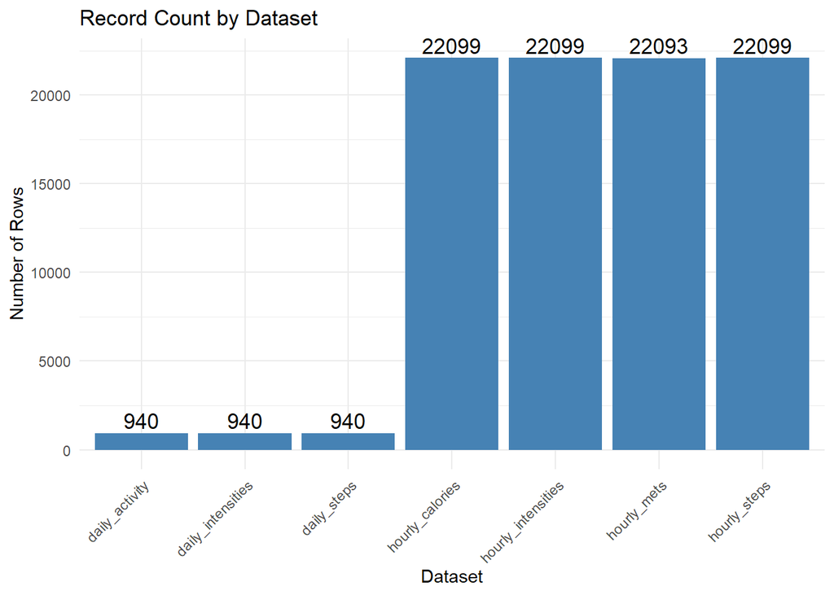

```r
library(dplyr)
library(tidyr)
library(ggplot2)
library(purrr)


## List of datasets
datasets <- list(
  daily_activity = daily_activity,
  daily_intensities = daily_intensities,
  daily_steps = daily_steps,
  hourly_steps = hourly_steps,
  hourly_intensities = hourly_intensities,
  hourly_calories = hourly_calories,
  hourly_mets = mets_hourly
)

record_counts <- tibble(
  Dataset = names(datasets),
  Rows = map_int(datasets, nrow)
)

ggplot(record_counts, aes(x = Dataset, y = Rows)) +
  geom_bar(stat = "identity", fill = "steelblue") +
  geom_text(aes(label = Rows), vjust = -0.3, size = 4.5) +
  labs(title = "Record Count by Dataset",
       x = "Dataset", y = "Number of Rows") +
  theme_minimal() +
  theme(axis.text.x = element_text(angle = 45, hjust = 1))
```

```r
summary(daily_activity)
```

```
##        Id             ActivityDate          TotalSteps    TotalDistance
##  Min.   :1.504e+09   Min.   :2016-04-12   Min.   :    0   Min.   : 0.000
##  1st Qu.:2.320e+09   1st Qu.:2016-04-19   1st Qu.: 3790   1st Qu.: 2.620
##  Median :4.445e+09   Median :2016-04-26   Median : 7406   Median : 5.245
##  Mean   :4.855e+09   Mean   :2016-04-26   Mean   : 7638   Mean   : 5.490
##  3rd Qu.:6.962e+09   3rd Qu.:2016-05-04   3rd Qu.:10727   3rd Qu.: 7.713
##  Max.   :8.878e+09   Max.   :2016-05-12   Max.   :36019   Max.   :28.030
##  TrackerDistance  LoggedActivitiesDistance VeryActiveDistance
##  Min.   : 0.000   Min.   :0.0000           Min.   : 0.000
##  1st Qu.: 2.620   1st Qu.:0.0000           1st Qu.: 0.000
##  Median : 5.245   Median :0.0000           Median : 0.210
##  Mean   : 5.475   Mean   :0.1082           Mean   : 1.503
##  3rd Qu.: 7.710   3rd Qu.:0.0000           3rd Qu.: 2.053
##  Max.   :28.030   Max.   :4.9421           Max.   :21.920
##  ModeratelyActiveDistance LightActiveDistance SedentaryActiveDistance
##  Min.   :0.0000           Min.   : 0.000      Min.   :0.000000
##  1st Qu.:0.0000           1st Qu.: 1.945      1st Qu.:0.000000
##  Median :0.2400           Median : 3.365      Median :0.000000
##  Mean   :0.5675           Mean   : 3.341      Mean   :0.001606
##  3rd Qu.:0.8000           3rd Qu.: 4.782      3rd Qu.:0.000000
##  Max.   :6.4800           Max.   :10.710      Max.   :0.110000
##  VeryActiveMinutes FairlyActiveMinutes LightlyActiveMinutes SedentaryMinutes
##  Min.   :  0.00    Min.   :  0.00      Min.   :  0.0        Min.   :   0.0
##  1st Qu.:  0.00    1st Qu.:  0.00      1st Qu.:127.0        1st Qu.: 729.8
##  Median :  4.00    Median :  6.00      Median :199.0        Median :1057.5
##  Mean   : 21.16    Mean   : 13.56      Mean   :192.8        Mean   : 991.2
##  3rd Qu.: 32.00    3rd Qu.: 19.00      3rd Qu.:264.0        3rd Qu.:1229.5
##  Max.   :210.00    Max.   :143.00      Max.   :518.0        Max.   :1440.0
##     Calories
##  Min.   :   0
##  1st Qu.:1828
##  Median :2134
##  Mean   :2304
##  3rd Qu.:2793
##  Max.   :4900
```

```r
summary(daily_calories)
```

```
##        Id             ActivityDay            Calories
##  Min.   :1.504e+09   Min.   :2016-04-12   Min.   :   0
##  1st Qu.:2.320e+09   1st Qu.:2016-04-19   1st Qu.:1828
##  Median :4.445e+09   Median :2016-04-26   Median :2134
##  Mean   :4.855e+09   Mean   :2016-04-26   Mean   :2304
##  3rd Qu.:6.962e+09   3rd Qu.:2016-05-04   3rd Qu.:2793
##  Max.   :8.878e+09   Max.   :2016-05-12   Max.   :4900
```

```r
summary(daily_intensities)
```

```
##        Id             ActivityDay         SedentaryMinutes LightlyActiveMinutes
##  Min.   :1.504e+09   Min.   :2016-04-12   Min.   :   0.0   Min.   :  0.0
##  1st Qu.:2.320e+09   1st Qu.:2016-04-19   1st Qu.: 729.8   1st Qu.:127.0
##  Median :4.445e+09   Median :2016-04-26   Median :1057.5   Median :199.0
##  Mean   :4.855e+09   Mean   :2016-04-26   Mean   : 991.2   Mean   :192.8
##  3rd Qu.:6.962e+09   3rd Qu.:2016-05-04   3rd Qu.:1229.5   3rd Qu.:264.0
##  Max.   :8.878e+09   Max.   :2016-05-12   Max.   :1440.0   Max.   :518.0
##  FairlyActiveMinutes VeryActiveMinutes SedentaryActiveDistance
##  Min.   :  0.00      Min.   :  0.00    Min.   :0.000000
##  1st Qu.:  0.00      1st Qu.:  0.00    1st Qu.:0.000000
##  Median :  6.00      Median :  4.00    Median :0.000000
##  Mean   : 13.56      Mean   : 21.16    Mean   :0.001606
##  3rd Qu.: 19.00      3rd Qu.: 32.00    3rd Qu.:0.000000
##  Max.   :143.00      Max.   :210.00    Max.   :0.110000
##  LightActiveDistance ModeratelyActiveDistance VeryActiveDistance
##  Min.   : 0.000      Min.   :0.0000           Min.   : 0.000
##  1st Qu.: 1.945      1st Qu.:0.0000           1st Qu.: 0.000
##  Median : 3.365      Median :0.2400           Median : 0.210
##  Mean   : 3.341      Mean   :0.5675           Mean   : 1.503
##  3rd Qu.: 4.782      3rd Qu.:0.8000           3rd Qu.: 2.053
##  Max.   :10.710      Max.   :6.4800           Max.   :21.920
```

```r
summary(daily_steps)
```

```
##        Id             ActivityDay           StepTotal
##  Min.   :1.504e+09   Min.   :2016-04-12   Min.   :    0
##  1st Qu.:2.320e+09   1st Qu.:2016-04-19   1st Qu.: 3790
##  Median :4.445e+09   Median :2016-04-26   Median : 7406
##  Mean   :4.855e+09   Mean   :2016-04-26   Mean   : 7638
##  3rd Qu.:6.962e+09   3rd Qu.:2016-05-04   3rd Qu.:10727
##  Max.   :8.878e+09   Max.   :2016-05-12   Max.   :36019
```

```r
summary(hourly_calories)
```

```
##        Id             ActivityHour                       Calories
##  Min.   :1.504e+09   Min.   :2016-04-12 00:00:00.00   Min.   : 42.00
##  1st Qu.:2.320e+09   1st Qu.:2016-04-19 01:00:00.00   1st Qu.: 63.00
##  Median :4.445e+09   Median :2016-04-26 06:00:00.00   Median : 83.00
##  Mean   :4.848e+09   Mean   :2016-04-26 11:46:42.58   Mean   : 97.39
##  3rd Qu.:6.962e+09   3rd Qu.:2016-05-03 19:00:00.00   3rd Qu.:108.00
##  Max.   :8.878e+09   Max.   :2016-05-12 15:00:00.00   Max.   :948.00
```

```r
summary(hourly_intensities)
```

```
##        Id             ActivityHour                    TotalIntensity
##  Min.   :1.504e+09   Min.   :2016-04-12 00:00:00.00   Min.   :  0.00
##  1st Qu.:2.320e+09   1st Qu.:2016-04-19 01:00:00.00   1st Qu.:  0.00
##  Median :4.445e+09   Median :2016-04-26 06:00:00.00   Median :  3.00
##  Mean   :4.848e+09   Mean   :2016-04-26 11:46:42.58   Mean   : 12.04
##  3rd Qu.:6.962e+09   3rd Qu.:2016-05-03 19:00:00.00   3rd Qu.: 16.00
##  Max.   :8.878e+09   Max.   :2016-05-12 15:00:00.00   Max.   :180.00
##  AverageIntensity
##  Min.   :0.0000
##  1st Qu.:0.0000
##  Median :0.0500
##  Mean   :0.2006
##  3rd Qu.:0.2667
##  Max.   :3.0000
```

```r
summary(hourly_steps)
```

```
##        Id             ActivityHour                      StepTotal
##  Min.   :1.504e+09   Min.   :2016-04-12 00:00:00.00   Min.   :    0.0
##  1st Qu.:2.320e+09   1st Qu.:2016-04-19 01:00:00.00   1st Qu.:    0.0
##  Median :4.445e+09   Median :2016-04-26 06:00:00.00   Median :   40.0
##  Mean   :4.848e+09   Mean   :2016-04-26 11:46:42.58   Mean   :  320.2
##  3rd Qu.:6.962e+09   3rd Qu.:2016-05-03 19:00:00.00   3rd Qu.:  357.0
##  Max.   :8.878e+09   Max.   :2016-05-12 15:00:00.00   Max.   :10554.0
```

# Data Analysis

We will analysze the processed 8 datasets further to find the trends and relationships of smart device usage of FitBit users and how could these trends apply to Bellabeat customers.

Import Libraries

```r
library(tidyverse)
library(dplyr)
library(ggplot2)
```

Data Aggregation When you look at the daily_activity dataset,you will see it contain all the information regarding calories,intensities,totat steps which are present as well in other daily_calories,daily_intensities and daily_steps dataset.We will VERIFY data first based on daily level containing all these information.

Verify Calories values in daily_activity and daily_calories dataset

```r
##  First, align column names and join
cal_check <- daily_activity %>%
  select(Id, Date = ActivityDate, Calories_activity = Calories) %>%
  left_join(daily_calories %>% rename(Date = ActivityDay, Calories_table = Calories), by = c("Id", "Date"))

##  Compare
all_equal_result_cal <- all.equal(cal_check$Calories_activity, cal_check$Calories_table, check.attributes = FALSE)
print(all_equal_result_cal)
```

```
## [1] TRUE
```

## Verify Steps values in daily_activity and daily_steps dataset

```r
steps_check <- daily_activity %>%
  select(Id, Date=ActivityDate, Steps_activity = TotalSteps) %>%
  left_join(daily_steps %>% rename(Date = ActivityDay, Steps_table = StepTotal), by = c("Id", "Date"))

all_equal_result_steps <- all.equal(steps_check$Steps_activity, steps_check$Steps_table, check.attributes = FALSE)
print(all_equal_result_steps)
```

```
## [1] TRUE
```

## Verify Intensities values in daily_activity and daily_intensities dataset

```r
##  Ensure date columns match
daily_activity <- daily_activity %>% rename(Date = ActivityDate)
daily_intensities <- daily_intensities %>% rename(Date = ActivityDay)

##  Join on Id and Date
joined_df <- daily_activity %>%
  left_join(daily_intensities, by = c("Id", "Date"), suffix = c("_act", "_int"))

common_cols <- intersect(names(daily_activity), names(daily_intensities))
common_cols <- setdiff(common_cols, c("Id", "Date"))  ##  exclude keys
print(common_cols)
```

```
## [1] "VeryActiveDistance"       "ModeratelyActiveDistance"
## [3] "LightActiveDistance"      "SedentaryActiveDistance"
## [5] "VeryActiveMinutes"        "FairlyActiveMinutes"
## [7] "LightlyActiveMinutes"     "SedentaryMinutes"
```

```r
##  Function to check equality for each column
check_column_match <- function(col) {
  act_col <- paste0(col, "_act")
  int_col <- paste0(col, "_int")
  diff <- abs(joined_df[[act_col]] - joined_df[[int_col]])
  mismatch_count <- sum(diff > 0, na.rm = TRUE)
  max_diff <- max(diff, na.rm = TRUE)

  tibble(
    Column = col,
    Matches = mismatch_count == 0,
    Mismatch_Count = mismatch_count,
    Max_Difference = max_diff
  )
}

##  For all shared columns between daily_activity and daily_intensities
comparison_detailed <- bind_rows(lapply(common_cols, check_column_match))
print(comparison_detailed)
```

```
## # A tibble: 8 × 4
##   Column                   Matches Mismatch_Count Max_Difference
##   <chr>                    <lgl>            <int>          <dbl>
## 1 VeryActiveDistance       TRUE                 0              0
## 2 ModeratelyActiveDistance TRUE                 0              0
## 3 LightActiveDistance      TRUE                 0              0
## 4 SedentaryActiveDistance  TRUE                 0              0
## 5 VeryActiveMinutes        TRUE                 0              0
## 6 FairlyActiveMinutes      TRUE                 0              0
## 7 LightlyActiveMinutes     TRUE                 0              0
## 8 SedentaryMinutes         TRUE                 0              0
```

Since all values in daily_activity is matching with individual dataset, We can hence drop daily_calories,daily_intensities and daily_steps datasets to simplify our analysis and thereby focus only on daily_activity dataset.

```r
rm(daily_calories,daily_steps,daily_intensities)
```

## Now combine hourly data into single dataset for calories,intensities and steps as well as MET’s

```r
hourly_steps <- hourly_steps %>% select(Id, ActivityHour, Steps = StepTotal)
hourly_calories <- hourly_calories %>% select(Id, ActivityHour, Calories)
hourly_intensities <- hourly_intensities %>% select(Id, ActivityHour,
  TotalIntensity, AverageIntensity)
mets_hourly <- mets_hourly %>% select(Id, ActivityHour=Hour, METs = Average_METs)

names(hourly_steps)
```

```
## [1] "Id"           "ActivityHour" "Steps"
```

```r
names(hourly_calories)
```

```
## [1] "Id"           "ActivityHour" "Calories"
```

```r
names(hourly_intensities)
```

```
## [1] "Id"               "ActivityHour"     "TotalIntensity"   "AverageIntensity"
```

```r
names(mets_hourly)
```

```
## [1] "Id"           "ActivityHour" "METs"
```

```r
hourly_combined <- hourly_steps %>%
  left_join(hourly_calories, by = c("Id", "ActivityHour")) %>%
  left_join(hourly_intensities, by = c("Id", "ActivityHour")) %>%
  left_join(mets_hourly, by = c("Id", "ActivityHour"))
```

```r
colSums(is.na(hourly_combined))
```

```
##               Id     ActivityHour            Steps         Calories
##                0                0                0                0
##   TotalIntensity AverageIntensity             METs
##                0                0                6
```

```r
hourly_combined[!complete.cases(hourly_combined), ]
```

```
## # A tibble: 6 × 7
##           Id ActivityHour        Steps Calories TotalIntensity AverageIntensity
##        <dbl> <dttm>              <dbl>    <dbl>          <dbl>            <dbl>
## 1 2022484408 2016-05-12 15:00:00   665      129             27           0.45
## 2 4445114986 2016-05-12 13:00:00    51       83              6           0.1
## 3 4445114986 2016-05-12 14:00:00   152       92             10           0.167
## 4 8378563200 2016-05-12 13:00:00   436      142             10           0.167
## 5 8378563200 2016-05-12 14:00:00    46      107              4           0.0667
## 6 8877689391 2016-05-12 14:00:00   457      113              9           0.15
## # ℹ 1 more variable: METs <dbl>
```

Since MET’s has 6 null values for 05/12/2016.We are going to replace it with 0.

```r
hourly_combined$METs[is.na(hourly_combined$METs)] <- 0
sum(is.na(hourly_combined$METs))
```

```
## [1] 0
```

## Removing individual hourly datasets

```r
rm(hourly_calories,hourly_intensities,hourly_steps,mets_hourly)
```

## Exporting cleaned data into csv for future reference/analysis

```r
## write.csv(daily_activity, "daily_activity_clean.csv", row.names = FALSE)
## write.csv(hourly_combined, "hourly_combined_clean.csv", row.names = FALSE)
```

## Add derived fields:

We are adding fields such as Week,weekday,whether if its a weekend or not,year to simplify our analysis for clear reporting.

```r
daily_activity$Weekday <- weekdays(daily_activity$Date)

daily_activity <- daily_activity %>%
  mutate(Week = isoweek(Date), Year = year(Date))

daily_activity$IsWeekend <- ifelse(daily_activity$Weekday %in% c("Saturday", "Sunday"), "Weekend", "Weekday")
```

## Categorize users

```r
daily_activity$ActivityLevel <- case_when(
  daily_activity$TotalSteps < 5000 ~ "Low",
  daily_activity$TotalSteps < 10000 ~ "Moderate",
  TRUE ~ "High"
)
```

## Calculate Average Daily Metrics (Per User)

```r
daily_summary <- daily_activity %>%
  group_by(Id) %>%
  summarise(
    Avg_Daily_Steps = mean(TotalSteps, na.rm = TRUE),
    Avg_Daily_Calories = mean(Calories, na.rm = TRUE),
    Total_Active_Minutes = mean(VeryActiveMinutes + FairlyActiveMinutes + LightlyActiveMinutes, na.rm = TRUE),
    Sedentary_Minutes = mean(SedentaryMinutes, na.rm = TRUE)
  )
daily_summary
```

```
## # A tibble: 33 × 5
##            Id Avg_Daily_Steps Avg_Daily_Calories Total_Active_Minutes
##         <dbl>           <dbl>              <dbl>                <dbl>
##  1 1503960366          12117.              1816.                278.
##  2 1624580081           5744.              1483.                168.
##  3 1644430081           7283.              2811.                209.
##  4 1844505072           2580.              1573.                117.
##  5 1927972279            916.              2173.                 40.7
##  6 2022484408          11371.              2510.                313.
##  7 2026352035           5567.              1541.                257
##  8 2320127002           4717.              1724.                202.
##  9 2347167796           9520.              2043.                287.
## 10 2873212765           7556.              1917.                328.
## # ℹ 23 more rows
## # ℹ 1 more variable: Sedentary_Minutes <dbl>
```

## Show the relationship between physical activity and energy expenditure

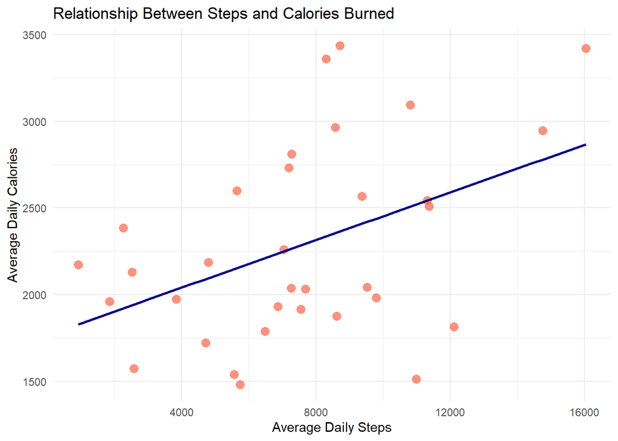

```r
ggplot(daily_summary, aes(x = Avg_Daily_Steps, y = Avg_Daily_Calories)) +
  geom_point(color = "tomato", size = 3, alpha = 0.7) +
  geom_smooth(method = "lm", se = FALSE, color = "darkblue") +
  labs(title = "Relationship Between Steps and Calories Burned",
       x = "Average Daily Steps", y = "Average Daily Calories") +
  theme_minimal()
```

This chart shows a positive correlation between average daily steps and calories burned — users who take more steps generally burn more calories. The trend line confirms this relationship, though individual differences exist. This insight supports promoting step-based goals to boost calorie expenditure among Bellabeat users.

## Determine Hourly Peak Activity Time

```r
hourly_combined %>%
  mutate(HourOnly = format(ActivityHour, "%H")) %>%
  group_by(HourOnly) %>%
  summarise(
    Avg_Steps = mean(Steps, na.rm = TRUE),
    Avg_Calories = mean(Calories, na.rm = TRUE),
    Avg_METs = mean(METs, na.rm = TRUE)
  ) %>%
  arrange(desc(Avg_METs))  ##  or Avg_Steps, etc.
```

```
## # A tibble: 24 × 4
##    HourOnly Avg_Steps Avg_Calories Avg_METs
##    <chr>        <dbl>        <dbl>    <dbl>
##  1 18            599.         123.     18.7
##  2 17            550.         123.     18.6
##  3 19            583.         121.     18.3
##  4 12            549.         117.     17.6
##  5 14            541.         116.     17.4
##  6 13            538.         115.     17.4
##  7 16            497.         113.     17.1
##  8 10            482.         110.     16.8
##  9 11            457.         110.     16.6
## 10 09            433.         106.     16.2
## # ℹ 14 more rows
```

## Calculate Weekly Consistency (Standard Deviation)

```r
## Calculate weekly step standard deviation per user
weekly_sd <- daily_activity %>%
  group_by(Id, Year, Week) %>%
  summarise(
    Step_SD = sd(TotalSteps, na.rm = TRUE),
    .groups = "drop"
  )
```

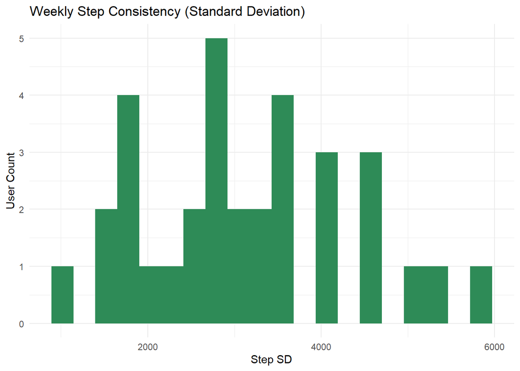

```r
## Average the standard deviation across weeks per user
weekly_user_consistency <- weekly_sd %>%
  group_by(Id) %>%
  summarise(
    Avg_Step_SD = mean(Step_SD, na.rm = TRUE),
    .groups = "drop"
  )

## Plot histogram of consistency
ggplot(weekly_user_consistency, aes(x = Avg_Step_SD)) +
  geom_histogram(fill = "seagreen", bins = 20) +
  labs(
    title = "Weekly Step Consistency (Standard Deviation)",
    x = "Step SD", y = "User Count"
  ) +
  theme_minimal()
```

## Exporting cleaned data into csv for sharing visualization in Tableau

```r
#write.csv(daily_activity, "daily_activity_clean_tableau.csv", row.names = FALSE)
#write.csv(hourly_combined, "hourly_combined_clean_tableau.csv", row.names = FALSE)
#write.csv(daily_summary, "user_summary_clean_tableau.csv", row.names = FALSE)
#write.csv(weekly_user_consistency, "weekly_user_consistency_clean_tableau.csv", row.names = FALSE)
```